# Team Styles

# Purpose

1. Team Scoring (good, bad, fun, boring)

# Get Games for Analysis

The 2019-2020 Spanish La Liga season (ID:775) will be used to initially create each visualization. The 2019-2020 German Bundesliga will then be used to verify the functionalized process resulting from the initial creation. All games scheduled on or after 2020-06-10 will be removed. Only completed games will be used.

```r
source('src/sports/soccer/get_league_games.R')
id1 <- 775
rawGames1 <- get_league_games(leagueId = id1)
```

```
No encoding supplied: defaulting to UTF-8.
```

```r
g1 <- rawGames1 %>%
    mutate(GameDate = lubridate::ymd(stringr::str_sub(string = GameTime, start = 1, end = 10))) %>%
    filter(GameDate < '2020-06-10') %>%
    select(HomeTeam, AwayTeam, HomeScore, AwayScore, HomeTeamLogoUrl, AwayTeamLogoUrl)
logos1 <- rawGames1 %>% select(Team = HomeTeam, Logo = HomeTeamLogoUrl) %>% distinct()
activeTeams1 <- c('Valencia' , 'Levante')
id2 <- 754
rawGames2 <- get_league_games(leagueId = id2)
```

```
No encoding supplied: defaulting to UTF-8.
```

```r
g2 <- rawGames2 %>%
    mutate(GameDate = lubridate::ymd(stringr::str_sub(string = GameTime, start = 1, end = 10))) %>%
    filter(GameDate < '2020-06-10') %>%
    select(HomeTeam, AwayTeam, HomeScore, AwayScore, HomeTeamLogoUrl, AwayTeamLogoUrl)
logos2 <- rawGames2 %>% select(Team = HomeTeam, Logo = HomeTeamLogoUrl) %>% distinct()
activeTeams2 <- c('Union Berlin', 'Hertha Berlin')
```

# Team Scoring

The team scoring viz will use an X-Axis of ascending points scored and a Y-Axis of descending points scored. This will result in 4 quadrants: - Good Team: Good Offense, Good Defense - Bad Team: Bad Offense, Bad Defense - Exciting Team: Good Offense, Bad Defense - Boring Team: Bad Offense, Good Defense

This will be based on the average goals for/against for each team. Additionally, the highlighting of teams provided in a vector should be supported.

First, the goal averages must be created.

```r
homeGoals <- g1 %>%
    group_by(HomeTeam) %>%
    summarise(GoalsFor = sum(HomeScore), GoalsAgainst = sum(AwayScore), Games = n()) %>%
    ungroup() %>%
    select(Team = HomeTeam, GoalsFor, GoalsAgainst, Games)
awayGoals <- g1 %>%
    group_by(AwayTeam) %>%
    summarise(GoalsFor = sum(AwayScore), GoalsAgainst = sum(HomeScore), Games = n()) %>%
    ungroup() %>%
    select(Team = AwayTeam, GoalsFor, GoalsAgainst, Games)
goals <- homeGoals %>%
    inner_join(awayGoals, by = 'Team') %>%
    mutate(GoalsFor = GoalsFor.x + GoalsFor.y,
           GoalsAgainst = GoalsAgainst.x + GoalsAgainst.y,
           Games = Games.x + Games.y,
           AvgGoalsFor = GoalsFor / Games,
           AvgGoalsAgainst = GoalsAgainst / Games) %>%
    inner_join(logos1, by = 'Team') %>%
    select(Team, AvgGoalsFor, AvgGoalsAgainst, Games, GoalsFor, GoalsAgainst, Logo) %>%
    arrange(-AvgGoalsFor, -AvgGoalsAgainst)
avgGoals <- mean(goals$AvgGoalsFor)
print(goals)
```

[output not shown]

Next, create the base graph using ggplot

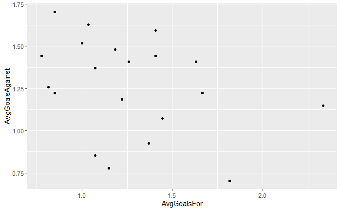

```r
ggplot(goals, aes(AvgGoalsFor, AvgGoalsAgainst)) +
    geom_point()
```

```r
ggplot(goals, aes(AvgGoalsFor, AvgGoalsAgainst)) +
    geom_point() +
    geom_abline(intercept = 0, slope = -1) +
    geom_vline(xintercept = avgGoals) +
    geom_hline(yintercept = avgGoals) +
    scale_y_reverse()
```

[output not shown]

## Change Points to Logos

This requires the ggimage package and changing from geom_point to geom_image

```r
library(ggimage)
ggplot(goals, aes(AvgGoalsFor, AvgGoalsAgainst)) +
    geom_image(aes(image = Logo), size = 0.05) +
    geom_abline(intercept = 0, slope = -1) +
    geom_vline(xintercept = avgGoals) +
    geom_hline(yintercept = avgGoals) +
    scale_y_reverse()
```

[output not shown]

## Make Axes Same Scale

[figure not shown]

```r
library(ggimage)
ggplot(goals, aes(AvgGoalsFor, AvgGoalsAgainst)) +
    geom_image(aes(image = Logo), size = 0.075) +
    geom_abline(intercept = 0, slope = -1) +
    geom_vline(xintercept = avgGoals) +
    geom_hline(yintercept = avgGoals) +
    coord_fixed(ratio = 1) +
    scale_y_reverse()
```

## Set Title and Axes

There are 3 types of text that need to be set: Plot Title, Axis Titles, and Quadrant Titles. The quadrant titles must be set relative to the visible plot (as opposed to being set based on coordinate location).

[figure not shown]

```r
library(ggimage)
library(grid)
ql.col <- 'red' # Quadrant Label Color
ql.sz <- 10 # Quadrant Label (Font) Size
ql.alpha = 0.3 # Quadrant Label Alpha
ggplot(goals, aes(AvgGoalsFor, AvgGoalsAgainst)) +
    geom_image(aes(image = Logo), size = 0.075) +
    geom_abline(intercept = 0, slope = -1) +
    geom_vline(xintercept = avgGoals) +
    geom_hline(yintercept = avgGoals) +
    coord_fixed(ratio = 1) +
    scale_y_reverse() +
    ggtitle('Team Scoring: Avg Goals For vs Avg Goals Against') +
    xlab('Average Goals For') +
    ylab('Average Goals Against (desc)') +
    annotation_custom(grobTree(textGrob('Good', x = 0.95, y = 0.95, gp = gpar(col = ql.col, fontsize = ql.sz, alpha = ql.alpha)))) +
    annotation_custom(grobTree(textGrob('Bad', x = 0.05, y = 0.05, gp = gpar(col = ql.col, fontsize = ql.sz, alpha = ql.alpha)))) +
    annotation_custom(grobTree(textGrob('Exciting', x = 0.95, y = 0.05, gp = gpar(col = ql.col, fontsize = ql.sz, alpha = ql.alpha)))) +
    annotation_custom(grobTree(textGrob('Boring', x = 0.05, y = 0.95, gp = gpar(col = ql.col, fontsize = ql.sz, alpha = ql.alpha))))
```

## Set Theme

[figure not shown]

```r
library(ggimage)
library(ggthemes)
ql.col <- 'red' # Quadrant Label Color
ql.sz <- 10 # Quadrant Label (Font) Size
ql.alpha = 0.3 # Quadrant Label Alpha
ggplot(goals, aes(AvgGoalsFor, AvgGoalsAgainst)) +
    geom_image(aes(image = Logo), size = 0.075) +
    geom_abline(intercept = 0, slope = -1) +
    geom_vline(xintercept = avgGoals) +
    geom_hline(yintercept = avgGoals) +
    coord_fixed(ratio = 1) +
    scale_y_reverse() +
    ggtitle('Team Scoring: Avg Goals For vs Avg Goals Against') +
    xlab('Average Goals For') +
    ylab('Average Goals Against (desc)') +
    annotation_custom(grobTree(textGrob('Good', x = 0.95, y = 0.95, gp = gpar(col = ql.col, fontsize = ql.sz, alpha = ql.alpha)))) +
    annotation_custom(grobTree(textGrob('Bad', x = 0.05, y = 0.05, gp = gpar(col = ql.col, fontsize = ql.sz, alpha = ql.alpha)))) +
    annotation_custom(grobTree(textGrob('Exciting', x = 0.95, y = 0.05, gp = gpar(col = ql.col, fontsize = ql.sz, alpha = ql.alpha)))) +
    annotation_custom(grobTree(textGrob('Boring', x = 0.05, y = 0.95, gp = gpar(col = ql.col, fontsize = ql.sz, alpha = ql.alpha)))) +
    theme_fivethirtyeight(base_size = 10, base_family = 'sans') +
    scale_color_fivethirtyeight() +
    theme(axis.title = element_text())
```

## Adjust Reference Line Styles

[figure not shown]

```r
library(ggimage)
library(ggthemes)
ql.col <- 'red' # Quadrant Label Color
ql.sz <- 10 # Quadrant Label (Font) Size
ql.alpha = 0.3 # Quadrant Label Alpha
rl.size = 0.25
avgGoalsLabel <- round(avgGoals, digits = 3)
ggplot(goals, aes(AvgGoalsFor, AvgGoalsAgainst)) +
    geom_image(aes(image = Logo), size = 0.075) +
    geom_abline(intercept = 0, slope = -1, color = 'red', size = rl.size) +
    geom_vline(xintercept = avgGoals, color = 'blue', size = rl.size) +
    geom_hline(yintercept = avgGoals, color = 'blue', size = rl.size) +
    coord_fixed(ratio = 1) +
    scale_y_reverse() +
    labs(
        title = 'Team Scoring: Avg Goals For vs Avg Goals Against',
        subtitle = paste0('Average League Goals: ', avgGoalsLabel),
        caption = 'Teams above/to the right of the red line have a positive goal differential.',
        x = 'Average Goals For',
        y = 'Average Goals Against (desc)'
    ) +
    annotation_custom(grobTree(textGrob('Good', x = 0.95, y = 0.95, gp = gpar(col = ql.col, fontsize = ql.sz, alpha = ql.alpha)))) +
    annotation_custom(grobTree(textGrob('Bad', x = 0.05, y = 0.05, gp = gpar(col = ql.col, fontsize = ql.sz, alpha = ql.alpha)))) +
    annotation_custom(grobTree(textGrob('Exciting', x = 0.95, y = 0.05, gp = gpar(col = ql.col, fontsize = ql.sz, alpha = ql.alpha)))) +
    annotation_custom(grobTree(textGrob('Boring', x = 0.05, y = 0.95, gp = gpar(col = ql.col, fontsize = ql.sz, alpha = ql.alpha)))) +
    theme_fivethirtyeight(base_size = 10, base_family = 'sans') +
    scale_color_fivethirtyeight()+
    theme(axis.title = element_text())
```

## Standardize Grid Lines

[figure not shown]

```r
library(ggimage)
library(ggthemes)
ql.col <- 'red' # Quadrant Label Color
ql.sz <- 10 # Quadrant Label (Font) Size
ql.alpha = 0.3 # Quadrant Label Alpha
rl.size = 0.25
avgGoalsLabel <- round(avgGoals, digits = 3)
ggplot(goals, aes(AvgGoalsFor, AvgGoalsAgainst)) +
    geom_image(aes(image = Logo), size = 0.075) +
    geom_abline(intercept = 0, slope = -1, color = 'red', size = rl.size) +
    geom_vline(xintercept = avgGoals, color = 'blue', size = rl.size) +
    geom_hline(yintercept = avgGoals, color = 'blue', size = rl.size) +
    coord_fixed(ratio = 1) +
    scale_x_continuous(minor_breaks = seq(from = 0, to = 10, by = 0.25)) +
    scale_y_continuous(minor_breaks = seq(from = 0, to = 10, by = 0.25), trans = 'reverse') +
    labs(
        title = 'Team Scoring: Avg Goals For vs Avg Goals Against',
        subtitle = paste0('Average League Goals: ', avgGoalsLabel),
        caption = 'Teams above/to the right of the red line have a positive goal differential.',
        x = 'Average Goals For',
        y = 'Average Goals Against (desc)'
    ) +
    annotation_custom(grobTree(textGrob('Good', x = 0.95, y = 0.95, gp = gpar(col = ql.col, fontsize = ql.sz, alpha = ql.alpha)))) +
    annotation_custom(grobTree(textGrob('Bad', x = 0.05, y = 0.05, gp = gpar(col = ql.col, fontsize = ql.sz, alpha = ql.alpha)))) +
    annotation_custom(grobTree(textGrob('Exciting', x = 0.95, y = 0.05, gp = gpar(col = ql.col, fontsize = ql.sz, alpha = ql.alpha)))) +
    annotation_custom(grobTree(textGrob('Boring', x = 0.05, y = 0.95, gp = gpar(col = ql.col, fontsize = ql.sz, alpha = ql.alpha)))) +
    theme_fivethirtyeight(base_size = 10, base_family = 'sans') +
    scale_color_fivethirtyeight() +
    theme(axis.title = element_text())
```

## Change “Goals” to “Score”

## Functionalize Graph and Test

```r
team_quality_quadrants <- function(homeTeamIds, awayTeamIds, homeScores, awayScores, homeLogoUrls, awayLogoUrls){
    teamGames <- data.frame(Team = c(homeTeamIds, awayTeamIds),
                            ScoreFor = c(homeScores, awayScores),
                            ScoreAgainst = c(awayScores, homeScores))

    teamLogos <- data.frame(Team = c(homeTeamIds, awayTeamIds), Logo = c(homeLogoUrls, awayLogoUrls)) %>% distinct()

    scores <- teamGames %>%
        group_by(Team) %>%
        summarise(ScoreFor = sum(ScoreFor),
                  ScoreAgainst = sum(ScoreAgainst),
                  Games = n()) %>%
        mutate(AvgScoreFor = ScoreFor / Games,
               AvgScoreAgainst = ScoreAgainst / Games) %>%
        inner_join(teamLogos, by = 'Team') %>%
        select(Team, AvgScoreFor, AvgScoreAgainst, Games, ScoreFor, ScoreAgainst, Logo) %>%
        arrange(-AvgScoreFor, -AvgScoreAgainst)

    avgScore <- mean(scores$AvgScoreFor)

    maxDecimalPlaces <- 2
    ql.col <- 'red' # Quadrant Label Color
    ql.sz <- 10 # Quadrant Label (Font) Size
    ql.alpha = 0.3 # Quadrant Label Alpha
    rl.size = 0.25

    avgScoreLabel <- format(round(avgScore, digits = maxDecimalPlaces), nsmall = maxDecimalPlaces)

    p <- ggplot(scores, aes(AvgScoreFor, AvgScoreAgainst)) +
        geom_image(aes(image = Logo), size = 0.075) +
        geom_abline(intercept =  0.0, slope = -1, color = ql.col, size = rl.size) +
        geom_vline(xintercept = avgScore, color = 'blue', size = rl.size) +
        geom_hline(yintercept = avgScore, color = 'blue', size = rl.size) +
        coord_fixed(ratio = 1) +
        scale_x_continuous(breaks = seq(from = 0, to = 200, by = 0.25)) +
        scale_y_continuous(breaks = seq(from = 0, to = 200, by = 0.25), trans = 'reverse') +
        labs(
            title = 'Team Scoring: Avg Score For vs Avg Score Against',
            subtitle = paste0('Average League Score: ', avgScoreLabel),
            caption = 'Teams above/to the right of the red line have a positive goal differential.'
        ) +
        xlab('Average Score For') +
        ylab('Average Score Against (desc)') +
        annotation_custom(grobTree(textGrob('Good', x = 0.95, y = 0.95, gp = gpar(col = ql.col, fontsize = ql.sz, alpha = ql.alpha)))) +
        annotation_custom(grobTree(textGrob('Bad', x = 0.05, y = 0.05, gp = gpar(col = ql.col, fontsize = ql.sz, alpha = ql.alpha)))) +
        annotation_custom(grobTree(textGrob('Exciting', x = 0.95, y = 0.05, gp = gpar(col = ql.col, fontsize = ql.sz, alpha = ql.alpha)))) +
        annotation_custom(grobTree(textGrob('Boring', x = 0.05, y = 0.95, gp = gpar(col = ql.col, fontsize = ql.sz, alpha = ql.alpha)))) +
        theme_fivethirtyeight(base_size = 10, base_family = 'sans') +
        scale_color_fivethirtyeight() +
        theme(axis.title = element_text())

    return(p)
}

testViz <- team_quality_quadrants(g2$HomeTeam, g2$AwayTeam, g2$HomeScore, g2$AwayScore, g2$HomeTeamLogoUrl, g2$AwayTeamLogoUrl)
testViz
```

[output not shown]

# Team Game Excitement

A high scoring game with a low margin of victory is generally more exciting for fans to watch. The Team Excitement Quadrants will have Average Goals Scored on the x-axis and Average Victory Margin on the y-axis. This will leave the following four quadrants.

- High Total, Low Margin: Electric
- High Total, High Margin: Slaughter
- Low Total, Low Margin: Battle/Grind
- Low Total, High Margin: Surgical/Tactical

## Create Team Game Excitement Function

[figure not shown]